# Loan Data from Prosper Marketplace Exploration

## by Maryam Shakeri

## Investigation Overview

> We investigate loan status and employment status and want to know how other factors like *BorrowerAPR*, *ProsperRating (numeric)*, *CreditScoreRangeLower*, *InquiriesLast6Months*, and *IncomeRange* affect them. Relationships between different variables are examined.

## Dataset Overview

> [Prosper Marketplace](https://en.wikipedia.org/wiki/Prosper_Marketplace), Inc. was founded in 2005 as the first peer-to-peer lending marketplace in San Francisco, California. Prosper Funding LLC, one of its subsidiaries, operates [Prosper.com](https://www.prosper.com/), a website where individuals can either invest in personal loans or request to borrow money. Prosper has facilitated more than 17 billion dollars in loans to more than 1,030,000 people (accessed on 11/11/2020, source: https://en.wikipedia.org/wiki/Prosper_Marketplace). Through Prosper, people can invest in each other in a way that is financially and socially rewarding. Borrowers apply online for a fixed-rate, fixed-term loan between 2,000 and 40,000. Individuals and institutions can invest in the loans and earn attractive returns. Prosper handles all loans servicing on behalf of the matched borrowers and investors. Prosper Marketplace is backed by leading investors including Sequoia Capital, Francisco Partners, Institutional Venture Partners, and Credit Suisse NEXT Fund (accessed on 11/11/2020, source: https://www.prosper.com/about)

> A small subset of data has been picked from [the origin prosper data](https://docs.google.com/spreadsheets/d/1gDyi_L4UvIrLTEC6Wri5nbaMmkGmLQBk-Yx3z0XDEtI/edit#gid=0) to do some exploration on it. The cleaned subset (df_sub_clean) has *14* columns, and *83982* rows. The columns are *ListingKey*, *ListingCreationDate*, *Term*, *LoanStatus*, *BorrowerAPR*, *ProsperRating (numeric)*, *ListingCategory (numeric)*, *EmploymentStatus*, *CreditScoreRangeLower*, *InquiriesLast6Months*, *IncomeRange*, *StatedMonthlyIncome*, *MonthlyLoanPayment* and *Year_listingCreation* (created column includes the years of the 'ListingCreationDate') for each borrower.

#### The Employment Status and Their Loan Status

> The vast majority of people applied for a loan from Prosper Marketplace was *Employed* (79.3%). About 9.4% and 5.3% were *Full-time*, and *Self-employed*, respectively. A minor portion of them is *Not employed*, *Retired*, and *Part-time*. For most *Employed* people, the loan status is *Current* and then *Completed* and *Chargedoff*, respectively. For *Full-time* people, the loan status is *Completed* and for *Self-employed* ones is *Current*.

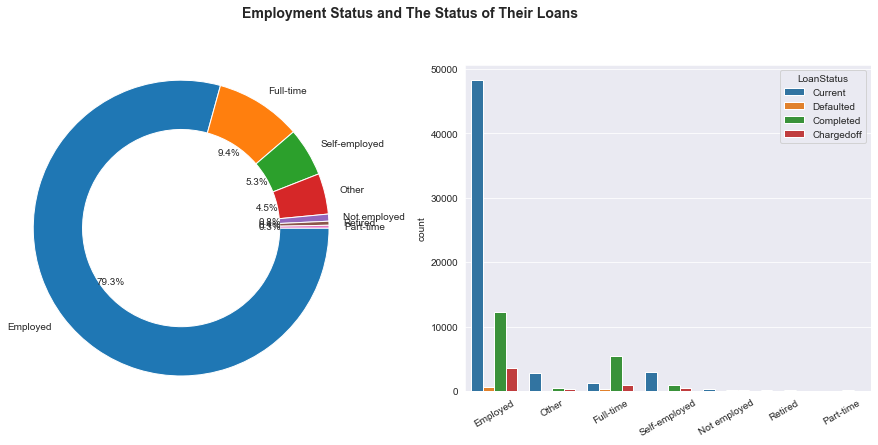

```python
plt.figure(figsize=[16,6]);
base_color = sb.color_palette('colorblind')[0];
# Set the aesthetic style of the plots.
sb.set_style('darkgrid');
plt.suptitle('Employment Status and The Status of Their Loans', fontsize=14, fontweight='semibold', y=1.015);

# Plot on left
plt.subplot(1, 2, 1);
# Use the result of value_counts() function for 'EmploymentStatus' and put it in the plt.pie function. It shows the percent of unique values in descending order.
employment_status = df_sub_clean['EmploymentStatus'].value_counts()
# Add a wedgeprops argument to the pie function to create a donut plot
plt.pie(employment_status, labels = employment_status.index, radius=1.2, autopct='%1.1f%%',
        counterclock = False, wedgeprops = {'width' : 0.4});
# Has the used option 'Square'
# https://matplotlib.org/api/_as_gen/matplotlib.pyplot.axis.html?highlight=pyplot%20axis#matplotlib-pyplot-axisplt.axis('square')
plt.axis('square');

# Plot on right
plt.subplot(1, 2, 2);
df_status=df_sub_clean.query('LoanStatus=="Completed" or LoanStatus=="Defaulted" or LoanStatus=="Chargedoff" or LoanStatus=="Current"')
sb.countplot(data = df_status, x = 'EmploymentStatus', hue = 'LoanStatus');
plt.xlabel('');
plt.xticks(rotation=30);
```

#### The Average of BorrowerAPR versus The Year_listingCreation for Loan Status from 2009 through 2014

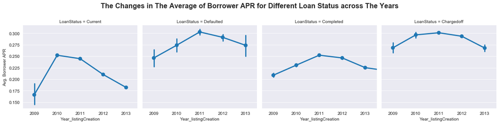

```python
# Use seaborn FacetGrid to facet bivariate plots (Year_listingCreation versus BorrowerAPR ) by the level of LoanStatus
base_color = sb.color_palette('colorblind')[0];
sb.set_style('darkgrid');

# df_status=df_sub_clean.query('LoanStatus=="Completed" or LoanStatus=="Defaulted" or LoanStatus=="Chargedoff" or LoanStatus=="Current"')
loan_apr = sb.FacetGrid(data = df_status, col = 'LoanStatus', size=4)
loan_apr.map(sb.pointplot, 'Year_listingCreation', 'BorrowerAPR')
loan_apr.fig.suptitle("The Changes in The Average of Borrower APR for Different Loan Status across The Years", size=16, fontweight='semibold')
# leave proper space on top for suptitle
loan_apr.fig.subplots_adjust(top=.8);
# Seaborn Facetgrid change ylabel
loan_apr.axes[0,0].set_ylabel('Avg. Borrower APR');
```

#### The Average of BorrowerAPR versus The Year_listingCreation for Employment Status from 2009 through 2014

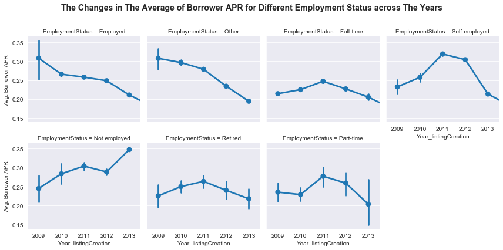

```python
# Use seaborn FacetGrid to facet bivariate plots (Year_listingCreation versus BorrowerAPR ) by the level of EmploymentStatus
base_color = sb.color_palette('colorblind')[0];
sb.set_style('darkgrid');

employ_apr = sb.FacetGrid(data = df_sub_clean, col = 'EmploymentStatus',col_wrap=4, size=3)
employ_apr.map(sb.pointplot, 'Year_listingCreation', 'BorrowerAPR')
employ_apr.set_axis_labels("Year_listingCreation", "Avg. Borrower APR")
employ_apr.fig.suptitle("The Changes in The Average of Borrower APR for Different Employment Status across The Years", size=14, fontweight='semibold')
employ_apr.fig.subplots_adjust(top=.85);
```

#### BorrowerAPR versus InquiriesLast6Months for Completed and Defaulted loans:

> *Defaulted* loans have fewer inquiries with higher APRs compared to *Completed* loans. *Completed* loans are more spread out in inquiries. It seems that fewer inquiries do not have a strong influence on reducing the amount of APR.

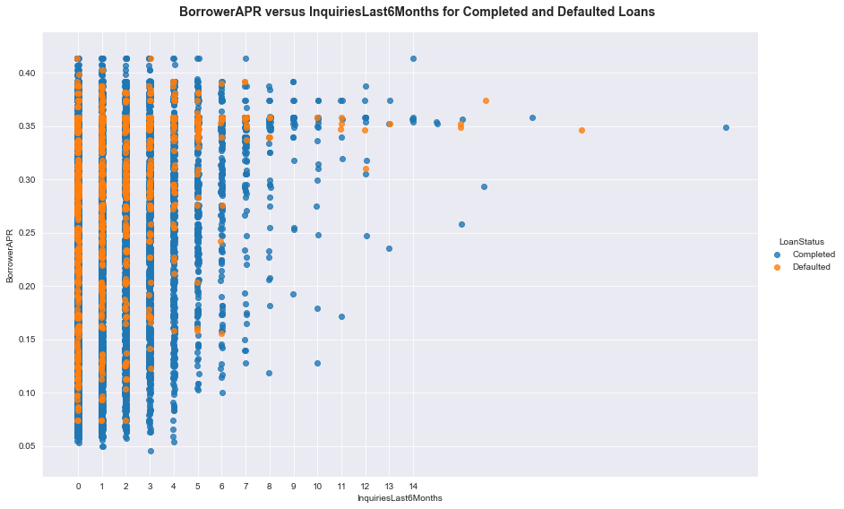

```python
# Use seaborn FacetGrid to facet bivariate plots (InquiriesLast6Months versus BorrowerAPR ) by the level of LoanStatus (Completed,Defaulted)
# Pick a dataframe that only include 'Completed' and 'Dedaulted' LoanStatus
df_stu=df_sub_clean.query('LoanStatus=="Completed" or LoanStatus=="Defaulted"')
inq_apr=sb.FacetGrid(data=df_stu,hue='LoanStatus', hue_order=['Completed','Defaulted'], size=8, aspect=1.5)
inq_apr=inq_apr.map(sb.regplot, 'InquiriesLast6Months', 'BorrowerAPR', x_jitter=0.04, fit_reg=False );
inq_apr.add_legend();
xticks=np.arange(0,15,1)
plt.xticks(xticks)
inq_apr.fig.suptitle("BorrowerAPR versus InquiriesLast6Months for Completed and Defaulted Loans", size=14, fontweight='semibold')
inq_apr.fig.subplots_adjust(top=.93);
```

#### BorrowerAPR versus InquiriesLast6Months for Employed and Not employed people:

> *Not Employed* people have fewer inqiries with higher APRs compared to *Employed*. *Employed* people are spread out in both inqiries and APRs.

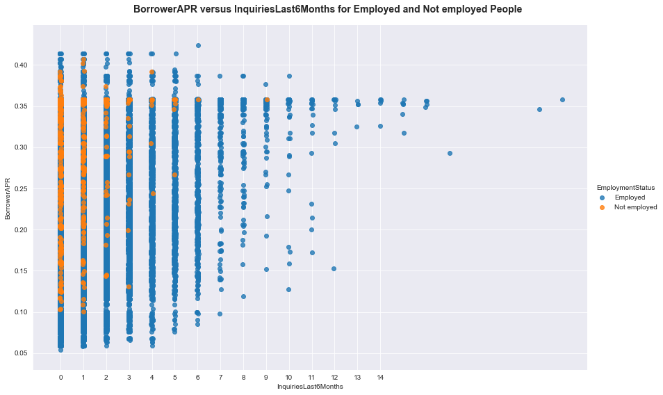

```python
# Use seaborn FacetGrid to facet bivariate plots (InquiriesLast6Months versus BorrowerAPR ) by the level of EmploymentStatus (Employed,Not employed)
# Pick a dataframe that only include 'Employed' and 'Not employed' EmploymentStatus
df_emp=df_sub_clean.query('EmploymentStatus=="Employed" or EmploymentStatus=="Not employed"')
inq_apr=sb.FacetGrid(data=df_emp,hue='EmploymentStatus', hue_order=['Employed','Not employed'], size=8, aspect=1.5)
ginq_apr=inq_apr.map(sb.regplot, 'InquiriesLast6Months', 'BorrowerAPR', x_jitter=0.04, fit_reg=False );
inq_apr.add_legend();
xticks=np.arange(0,15,1)
plt.xticks(xticks);
inq_apr.fig.suptitle("BorrowerAPR versus InquiriesLast6Months for Employed and Not employed People", size=14, fontweight='semibold')
inq_apr.fig.subplots_adjust(top=.93);
```

#### BorrowerAPR versus CreditScoreRangeLower for Completed and Defaulted loans:

> APR and CreditScoreRangeLower are scattered for both *Completed* and *Defaulted* loans. Most *Defaulted* loans have higher APR and less CreditScoreRangeLower compared to *Completed*. As seen, both *Completed* and *Defaulted* loans with less CreditScoreRangeLower have higher APRs. By increasing CreditScoreRangeLower, their APRs are reducing. The BorrowerAPR has a moderate negative correlation with the 'CreditScoreRangeLower'.

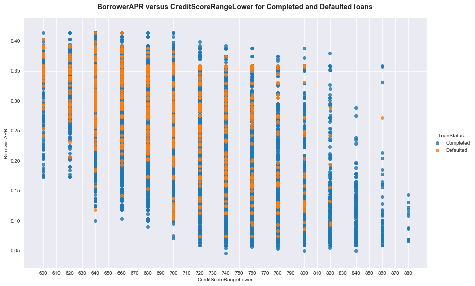

```python
# Use seaborn FacetGrid to facet bivariate plots (CreditScoreRangeLower versus BorrowerAPR ) by the level of LoanStatus (Completed,Defaulted)
crt_apr=sb.FacetGrid(data=df_stu,hue='LoanStatus', hue_order=['Completed','Defaulted'], size=8, aspect=1.5)
crt_apr=crt_apr.map(sb.regplot, 'CreditScoreRangeLower', 'BorrowerAPR', x_jitter=0.04, fit_reg=False );
crt_apr.add_legend();
xticks=np.arange(600,880+10,10)
plt.xticks(xticks);
crt_apr.fig.suptitle("BorrowerAPR versus CreditScoreRangeLower for Completed and Defaulted loans", size=14, fontweight='semibold')
crt_apr.fig.subplots_adjust(top=.93);
```

#### BorrowerAPR versus CreditScoreRangeLower for Employed and Not employed people:

> CreditScoreRangeLower is more scattered for *Employed* people. Most *Not employed* people have higher APR and less CreditScoreRangeLower compared to *Employed* people. Also, for most *Not employed* people, their APRs did not reduce by increasing their CreditScoreRangeLower.

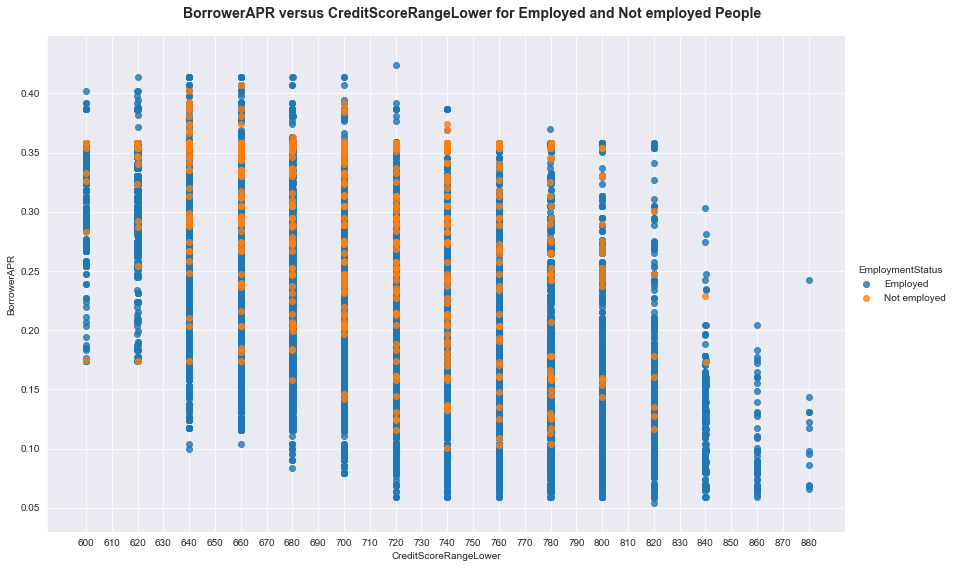

```python
# Use seaborn FacetGrid to facet bivariate plots (CreditScoreRangeLower versus BorrowerAPR ) by the level of EmploymentStatus (Employed,Not employed)
crt_apr=sb.FacetGrid(data=df_emp,hue='EmploymentStatus', hue_order=['Employed','Not employed'], size=8, aspect=1.5)
crt_apr=crt_apr.map(sb.regplot, 'CreditScoreRangeLower', 'BorrowerAPR', x_jitter=0.04, fit_reg=False );
crt_apr.add_legend();
xticks=np.arange(600,880+10,10)
plt.xticks(xticks);
crt_apr.fig.suptitle("BorrowerAPR versus CreditScoreRangeLower for Employed and Not employed People", size=14, fontweight='semibold')
crt_apr.fig.subplots_adjust(top=.93);
```

#### ProsperRating (numeric) versus LoanStatus in different Term of loans:

> For 12-month-term loans, the *Current* and *Defaulted* loans have higher prosper-ratings. Also, the *Current* loan is more spread out in the prosper-rating compared to the others. The *Completed* loan has a prosper-rating between 2 and 3.

> For 36-month-term loans, the *Current* and *Chargedoff* loans have higher prosper-ratings. All have wider distributions compared to the other Terms (12 and 60).

> For 60-month-term loans, as seen, the distribution of prosper-rating is the same for the *Completed*, *Chargedoff*, and *Defaulted* loans.

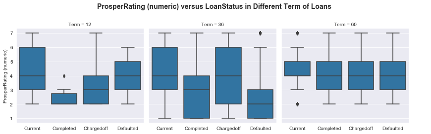

```python
# # Use seaborn FacetGrid to facet bivariate plots (LoanStatus versus ProsperRating (numeric) ) by the level of Term
base_color = sb.color_palette()[0]

g = sb.FacetGrid(data = df_status, col = 'Term', size = 4,
                margin_titles = True)
g.map(sb.boxplot,'LoanStatus','ProsperRating (numeric)', color = base_color);
g.set_axis_labels('','ProsperRating (numeric)')
g.add_legend();
g.fig.suptitle("ProsperRating (numeric) versus LoanStatus in Different Term of Loans", size=14, fontweight='semibold' )
g.fig.subplots_adjust(top=.8);
```

#### ProsperRating (numeric) versus EmploymentStatus in different Term of loans:

> For 36-month-term loans, the *Other* has less prosper-rating, and the *Employed*, *Self-employed* and *Not employed* people have higher values (the distribution of prosper-rating for the *Employed* and *Self-employed* is right-skewed and for *Not employed* is left-skewed).

> For 60-month-term loans, the highest prosper-rating belongs to the *Retired* people.

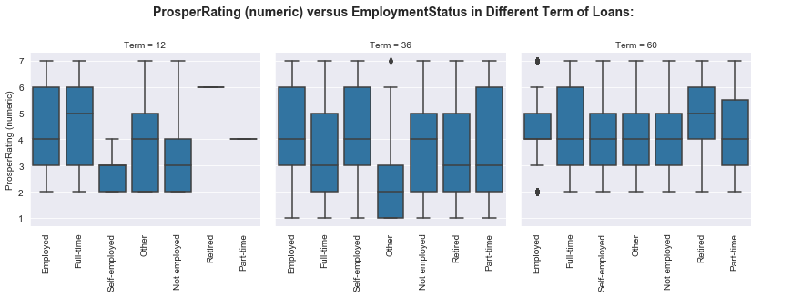

```python
# # Use seaborn FacetGrid to facet bivariate plots (EmploymentStatus versus ProsperRating (numeric) ) by the level of Term
base_color = sb.color_palette()[0]

g = sb.FacetGrid(data = df_status, col = 'Term', size = 4,
                margin_titles = True)
g.map(sb.boxplot,'EmploymentStatus','ProsperRating (numeric)', color = base_color);
g.set_axis_labels('','ProsperRating (numeric)')
g.set_xticklabels(rotation=90)
g.add_legend();
g.fig.suptitle("ProsperRating (numeric) versus EmploymentStatus in Different Term of Loans:", size=14, fontweight='semibold')
g.fig.subplots_adjust(top=.8);
```

#### The IncomeRange for Different Loan Status across The Loan Terms

> Most loans with *Term 12* are *Completed* that have income range of 50,000-74,999 dollars. Then, the income ranges were 100,000+, and 25,000-49,999 and 75,000-99,999 dollars, respectively. Most loans with *Term 36* and *60* are *Current* with income range of 50,000-74,999, and 25,000-49,999 dollars. In 36-month loans, after the *Current*, the most is *Completed* loan with an income range of 25,000-49,999 and 50,000-74,999 dollars.

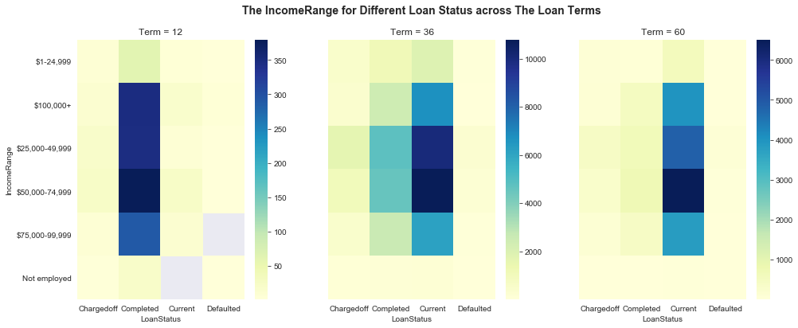

```python
plt.figure(figsize=(16, 6))
plt.suptitle('The IncomeRange for Different Loan Status across The Loan Terms', fontsize=14, fontweight='semibold')

# First plot
plt.subplot(1, 3, 1)
# Drop income range equal to '$0'
df_status=df_status[df_status.IncomeRange != '$0']
# For Term = 12, use group_by() and size() to get the number of LoanStatus and each combination of the two variable levels as a pandas Series and then use .reset_index() to convert a series into a dataframe object
df_1=df_status.query('Term==12').groupby(['IncomeRange', 'LoanStatus'])['ListingKey'].size().reset_index()
# Use DataFrame.pivot() to rearrange the data, to have IncomeRange, on rows
df_1 = df_1.pivot('IncomeRange', 'LoanStatus', 'ListingKey')
sb.heatmap(df_1, cmap="YlGnBu");
# Use the plt.yticks function to set rotation=0
plt.yticks(rotation=0);
plt.title("Term = 12", y=1.015)
plt.xlabel('LoanStatus')
plt.ylabel( 'IncomeRange');

# Second plot
plt.subplot(1, 3, 2)
df_1=df_status.query('Term==36').groupby(['IncomeRange', 'LoanStatus'])['ListingKey'].size().reset_index()
df_1 = df_1.pivot('IncomeRange', 'LoanStatus', 'ListingKey')
sb.heatmap(df_1, cmap="YlGnBu");
ax1 = plt.subplot(1, 3, 2)
# Remove yticks from pyplot subplot
ax1.set_yticks([], [])
plt.title("Term = 36", y=1.015)
plt.xlabel('LoanStatus')
plt.ylabel( '');

# Third plot
plt.subplot(1, 3, 3)
df_1=df_status.query('Term==60').groupby(['IncomeRange', 'LoanStatus'])['ListingKey'].size().reset_index()
df_1 = df_1.pivot('IncomeRange', 'LoanStatus', 'ListingKey')
sb.heatmap(df_1, cmap="YlGnBu");
ax2 = plt.subplot(1, 3, 3)
ax2.set_yticks([], [])
plt.title("Term = 60", y=1.015)
plt.xlabel('LoanStatus')
plt.ylabel( '');
```

#### The IncomeRange for Different Employment Status across The Loan Terms

> In all *12*, *36*, and *60 Terms*, most *Employed* people have an income range of 50,000-74,999 and 25,000-49,999 dollars who applied for loans. Also, in *Term 12*, most of them that applied for a loan had an income range of 100,000+ dollars.

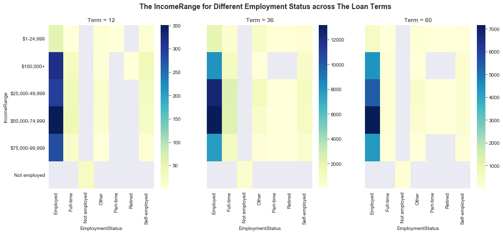

```python
plt.figure(figsize=(16,6))
plt.suptitle('The IncomeRange for Different Employment Status across The Loan Terms', fontsize=14, fontweight='semibold')

# First plot
plt.subplot(1, 3, 1)
# Drop income range equal to '$0'
df_sub_clean=df_sub_clean[df_sub_clean.IncomeRange != '$0']
# For Term = 12, use group_by() and size() to get the number of EmploymentStatus and each combination of the two variable levels as a pandas Series and then use .reset_index() to convert a series into a dataframe object
df_1=df_sub_clean.query('Term==12').groupby(['IncomeRange', 'EmploymentStatus'])['ListingKey'].size().reset_index()
# Use DataFrame.pivot() to rearrange the data, to have IncomeRange, on rows
df_1 = df_1.pivot('IncomeRange', 'EmploymentStatus', 'ListingKey')
sb.heatmap(df_1, cmap="YlGnBu");
# Use the plt.yticks function to set rotation=0
plt.yticks(rotation=0);
plt.title("Term = 12", y=1.015)
plt.xlabel('EmploymentStatus')
plt.ylabel( 'IncomeRange');

# Second plot
plt.subplot(1, 3, 2)
df_1=df_sub_clean.query('Term==36').groupby(['IncomeRange', 'EmploymentStatus'])['ListingKey'].size().reset_index()
df_1 = df_1.pivot('IncomeRange', 'EmploymentStatus', 'ListingKey')
sb.heatmap(df_1, cmap="YlGnBu");
ax1 = plt.subplot(1, 3, 2)
# Remove yticks from pyplot subplot
ax1.set_yticks([], [])
plt.title("Term = 36", y=1.015)
plt.xlabel('EmploymentStatus')
plt.ylabel( '');

# Third plot
plt.subplot(1, 3, 3)
df_1=df_sub_clean.query('Term==60').groupby(['IncomeRange', 'EmploymentStatus'])['ListingKey'].size().reset_index()
df_1 = df_1.pivot('IncomeRange', 'EmploymentStatus', 'ListingKey')
sb.heatmap(df_1, cmap="YlGnBu");
ax2 = plt.subplot(1, 3, 3)
ax2.set_yticks([], [])
plt.title("Term = 60", y=1.015)
plt.xlabel('EmploymentStatus')
plt.ylabel( '');
```

```python
! jupyter nbconvert prosper_loan_slide_deck.ipynb --to slides --post serve --template output_toggle
```

[output not shown]